# Data validation and cleaning

I am trying to use R Notebook instead of standard R Markdown, as it may be more readable than a raw R Script and more flexible than typical R Markdown.

# 1 Reading from pre-processed RDS

See `002_read-date.R` for details. Using `here` package already loaded before, we can simply locate our files. Just type `here("")` and (with the cursor right in between the quotation marks) press Tab for obtaining nice list of available files. No need to type and get typos…

Also, solve the packages namespace conflict problem. Package `conflicted` from *tidyverse* does the job nice and clean. Another option is to “rewrite” the function, e.g. `select <- dplyr::select`.

```r
source("shared.R")
library(assertr)
library(conflicted)
library(corrr)
library(here)
library(lubridate)
library(magrittr)
library(mirt)
library(naniar)
library(reschola)
library(tidyverse)
library(visdat)

# resolve conflicts
conflict_prefer("here", "here")
```

```
[conflicted] Will prefer here::here over any other package
```

```r
conflict_prefer("filter", "dplyr")
```

```
[conflicted] Will prefer dplyr::filter over any other package
```

```r
dfm <- read_rds(here("data-intermediate/waves_1-8.rds"))
```

# 2 Validating

## 2.1 With `assertr`

`assetr` is especially useful when you know something is impossible and should not run without any warning nor let be unnoticed. For details, see the [vignette](https://cran.r-project.org/web/packages/assertr/vignettes/assertr.html) and [functions reference](https://docs.ropensci.org/assertr/reference/).

Basic functions with examples from `mtcars`:

- `verify(mpg > 0)` – for simple check if specified variable is positive number
- `assert(within_bounds(0, 100), mpg)` – check if `mpg` variable is within specified bounds, it is easy to select more variables with `dplyr`-like manner, so you can select all variables *except* `mpg` with `-mpg` (difference between verify and assert is that verify takes an expression, and assert takes a predicate and columns to apply it to[^1]); the built-in predicates are `not_na`, `within_bounds`, `in_set`, and `is_uniq`
- `insist(within_n_mads(3), mpg)` – when we are validating against unknown value that needs to be computed first column-by-column; in this particular example MADS is used instead of SD, because the outliers could make SD useless
- `insist_rows(maha_dist, within_n_mads(3), everything())` – row-wise approach, e.g. for identifying outliers based on Mahalanobis’ distance
- `assert_rows(num_row_NAs, within_bounds(0, 2)` – row-wise `assert` approach, identifying cases with 0-2 NAs (in the example)

These functions can be “pipelined”. Success and error evaluations can be modified (see `help("success_and_error_functions")`).

```r
gender_check <- dfm %>%
  assert(
    in_set("boys", "girls"),
    gender_girl,
    success_fun = success_logical,
    error_fun = error_df_return
  )
gender_check
```

```
[1] TRUE
```

```r
months_check <- dfm %>%
  assert(
    within_bounds(1, 12),
    fill_in_month,
    born_month,
    success_fun = success_logical,
    error_fun = error_df_return
  )
months_check
```

```
[1] TRUE
```

```r
years_check <- dfm %>%
  insist(
    within_n_mads(3),
    fill_in_year,
    born_year,
    success_fun = success_logical,
    error_fun = error_df_return
  )
years_check
```

| verb | redux_fn | predicate | column | index | value |
| --- | --- | --- | --- | --- | --- |
| insist | NA | within_n_mads(3) | fill_in_year | 1350 | 2108 |
| insist | NA | within_n_mads(3) | born_year | 5518 | 1987 |

Apparently, we have one typo in year and one subject that is not intended to be evaluated with the rest (test subject by ID…). We can repair the first and exclude the second.

```r
# repair nonsensical value with the most likely value
# and filter the test subject with slice function (note the - sign!)
dfm %<>%
  slice(-(years_check %>% filter(column == "born_year") %>% pull(index))) %>%
  mutate(fill_in_year = ifelse(fill_in_year == 2108, 2018, fill_in_year))

# check if solved
dfm %>% insist(
  within_n_mads(3),
  fill_in_year,
  born_year,
  success_fun = success_logical,
  error_fun = error_df_return
)
```

```
[1] TRUE
```

## 2.2 Auxiliary/derived variables

Make `born` and `fill_in_date` vars, returning NA when any original parts is NA.

```r
dfm %<>% mutate(born = ymd(if_else(
  is.na(born_year) | is.na(born_month), NA_character_,
  paste(born_year, born_month, "1", sep = "-")
)),
fill_in_date = ymd(if_else(
  is.na(fill_in_year) | is.na(fill_in_month), NA_character_,
  paste(fill_in_year, fill_in_month, "1", sep = "-")
)))
```

Rank measurements by `fill_in_date`, only for IDs having complete dates filled in.

```r
wave_rank <- dfm %>%
  group_by(id_pupil) %>%
  filter(!any_na(fill_in_date)) %>% # exclude any NA in fill_in_date
  mutate(wave_rank = dense_rank(fill_in_date)) %>%
  ungroup %>%
  select(rowid, wave_rank)

# merge back to original dataset
dfm %<>% left_join(wave_rank)
```

## 2.3 Custom checks

However, to my knowledge and for our purposes, `assertr` nor any other “validating” package can spot IDs changing gender, birthday nor “messed-up” IDs referring to multiple subjects. Thus, there is a need to write proprietary functions as follows.

```r
spot_weirdos <- function(df, id, var, type) {
  id <- enquo(id)
  var <- enquo(var)

  if (type %in% c("unique", "u")) {
    df %>%
      group_by(!!id) %>%
      summarise(n = n_distinct(!!var, na.rm = T)) %>%
      filter(n > 1) %>%
      pull(!!id) %>%
      unique
  } else if (type %in% c("nonrepeating", "nr")) {
    df %>%
      filter(!is.na(!!var)) %>%
      count(!!id, !!var) %>%
      filter(n > 1) %>%
      pull(!!id) %>%
      unique
  }
}
```

Function `spot_weirdo(dataframe, id variable, variable of interest, type of variable)` returns IDs of so-called “weirdos”, i.e. IDs with “weird” variable. This weirdness can be of two type – variable is either expected to:

1. be unique within ID (e.g. gender) – i.e. `type = "unique"` or `type = "u"`
2. having one value only once (e.g. measurement number) – i.e. `type = "nonrepeating"` or `type = "nr"`

You need to specify the ID variable, the variable “weirdos” is meant to be spotted on, and the type of weirdness. Feel free to use it in a pipeline. Note that NAs (**not explicit NAs** by `forcats`) are completely ignored. Please avoid using explicit NAs, as `n_distinct` function does not consider them as “proper” NAs.

`spot_weirdo` in action:

```r
nuniq_born <- dfm %>% spot_weirdos(id_pupil, born, "u")
nuniq_gender <- dfm %>% spot_weirdos(id_pupil, gender_girl, "u")
nuniq_wave_ind <- dfm %>% spot_weirdos(id_pupil, wave_ind, "nr")
nuniq_wave_rank <- dfm %>% spot_weirdos(id_pupil, wave_rank, "nr")
```

## 2.4 Duplicates

Moreover, it is useful to check whether the dataset contains any duplicates. We are lenient to typos and are considering only the most crucial variables. REGEX expression refers to all SDQ items (they always begin with “t” and do not contain any "_").

```r
distinct_rowids <- dfm %>%
  distinct_at(vars(id_pupil, gender_girl, born, wave, matches("^t[^_]+$")), .keep_all = T) %>%
  pull(rowid)

duplicates <- dfm %>% filter(!rowid %in% distinct_rowids) %>% pull(id_pupil) %>% unique
```

## 2.5 Conclusion

Let’s have a look at the problem (and the scale of it). First, make new variables indicating whether an ID has any problem.

```r
dfm %<>% mutate(
  invalid_wave_ind = if_else(id_pupil %in% nuniq_wave_ind, TRUE, FALSE),
  invalid_gender = if_else(id_pupil %in% nuniq_gender, TRUE, FALSE),
  invalid_born = if_else(id_pupil %in% nuniq_born, TRUE, FALSE),
  invalid_wave_rank = if_else(id_pupil %in% nuniq_wave_rank, TRUE, FALSE),
  invalid_duplicate = if_else(id_pupil %in% duplicates, TRUE, FALSE)
)

# global invalid var
dfm %<>% mutate(invalid_case = if_else(rowSums(select(., contains("invalid"))) == 0, FALSE, TRUE))
```

How many invalid IDs do we have?

```r
dfm %>% count(
  invalid_wave_ind,
  invalid_gender,
  invalid_born,
  invalid_wave_rank,
  invalid_duplicate
)
```

| invalid_wave_ind | invalid_gender | invalid_born | invalid_wave_rank | invalid_duplicate | n |
| --- | --- | --- | --- | --- | --- |
| FALSE | FALSE | FALSE | FALSE | FALSE | 5752 |
| FALSE | FALSE | TRUE | FALSE | FALSE | 116 |
| FALSE | TRUE | FALSE | FALSE | FALSE | 162 |
| FALSE | TRUE | TRUE | FALSE | FALSE | 18 |
| TRUE | FALSE | FALSE | TRUE | FALSE | 21 |
| TRUE | FALSE | TRUE | TRUE | FALSE | 96 |
| TRUE | TRUE | TRUE | TRUE | FALSE | 181 |

Impact of cleaning by **WAVE_IND** (measurement)

```r
cleaning_impact_wave_ind <- dfm %>% filter_at(vars(contains("invalid")), all_vars(. == FALSE)) %>%
  count(wave_ind) %>%
  left_join(dfm %>% count(wave_ind), ., by = "wave_ind") %>%
  mutate(diff = n.x - n.y, "% lost" = ((1 - (n.y / n.x)) * 100)) %>%
  rename("# raw" = 2,
         "# cleaned" = 3,
         "# lost" = 4)

cleaning_impact_wave_ind
```

| wave_ind | # raw | # cleaned | # lost | % lost |
| --- | --- | --- | --- | --- |
| 1 | 2165 | 2028 | 137 | 6.327945 |
| 2 | 1969 | 1833 | 136 | 6.907059 |
| 3 | 923 | 794 | 129 | 13.976165 |
| 4 | 896 | 740 | 156 | 17.410714 |
| 5 | 200 | 181 | 19 | 9.500000 |
| 6 | 193 | 176 | 17 | 8.808290 |

```r
cleaning_impact_wave_ind %>% write_csv("data-processed/cleaning_impact_wave_ind.csv")
```

Impact of cleaning impact by **WAVE**

```r
cleaning_impact_wave <- dfm %>% filter_at(vars(contains("invalid")), all_vars(. == FALSE)) %>% count(wave) %>%
  left_join(dfm %>% count(wave), ., by = "wave") %>%
  mutate(diff = n.x - n.y, "% lost" = ((1 - (n.y / n.x)) * 100)) %>%
  rename("# raw" = 2,
         "# cleaned" = 3,
         "# lost" = 4)

cleaning_impact_wave
```

| wave | # raw | # cleaned | # lost | % lost |
| --- | --- | --- | --- | --- |
| 1 | 465 | 446 | 19 | 4.086022 |
| 2 | 485 | 464 | 21 | 4.329897 |
| 3 | 905 | 856 | 49 | 5.414365 |
| 4 | 866 | 815 | 51 | 5.889145 |
| 5 | 1093 | 974 | 119 | 10.887466 |
| 6 | 1060 | 942 | 118 | 11.132075 |
| 7 | 737 | 642 | 95 | 12.890095 |
| 8 | 735 | 613 | 122 | 16.598639 |

```r
cleaning_impact_wave %>% write_csv("data-processed/cleaning_impact_wave.csv")
```

### 2.5.1 Cases with nonconsecutive measurment

It may be useful to see how many IDs diverge from expected measurement (`wave_ind`) sequence. Note that this is intentional – when someone skips the wave, so does his or her `wave_ind`.

```r
noncosecutives <- dfm %>%
  group_by(id_pupil) %>%
  mutate(
    wave_ind_presumed = seq(1, max(wave_ind, na.rm = T)) %>% str_flatten,
    wave_ind_actual = sort(wave_ind) %>% str_flatten,
    by_date = sort(wave_rank) %>% str_flatten()
  ) %>% filter(wave_ind_actual != wave_ind_presumed) %>%
  ungroup()
```

Counts of nonconsecutive cases by their “validity status”

```r
noncosecutives %>% count(invalid_case)
```

| invalid_case | n |
| --- | --- |
| FALSE | 91 |
| TRUE | 311 |

Example:

```r
noncosecutives %>% select(id_pupil, wave_ind_presumed, wave_ind_actual) %>% sample_n(6)
```

| id_pupil | wave_ind_presumed | wave_ind_actual |
| --- | --- | --- |
| 02-0396 | 123456 | 12456 |
| 01-0158 | 123456 | 12456 |
| 10-0026 | 1234 | 12334 |
| 02-0393 | 123456 | 12346 |
| 18-0005 | 12 | 122 |
| 10-0006 | 1234 | 1233444 |

### 2.5.2 Filtering

For now on, we work with *clean* dataset only. It could be changed via editing this filter:

```r
dfm %<>% filter_at(vars(contains("invalid")), all_vars(. == FALSE))
```

## 2.6 Auxiliary/derived variable *after* filtering

`Age` and `age at the first measurement` variables can be derived in straightforward way only after main filtering is done.

### 2.6.1 Age at measurement and age at first measurement

```r
# get time interval in years
dfm %<>% mutate(age = interval(born, fill_in_date) %>% as.numeric('years'))

# get cases with known birthday; only one value per ID
birthdays <-
  dfm %>% drop_na(born) %>% distinct_at(vars(id_pupil, born))

# get fill in date of the first measurement; NAs are dropped
fill_in_date_fst_measur <-
  dfm %>% drop_na(fill_in_date) %>%
  filter(wave_ind == 1) %>%
  select(id_pupil, fill_in_date)

born_age <-
  left_join(birthdays, fill_in_date_fst_measur) %>%
  na.omit %>%
  mutate(age_fst_measur = interval(born, fill_in_date) %>%
           as.numeric('years')) %>%
  select(id_pupil, age_fst_measur)
dfm %<>% left_join(born_age, by = "id_pupil")
```

## 2.7 Descriptive visualizations / statistics

Quick overview:

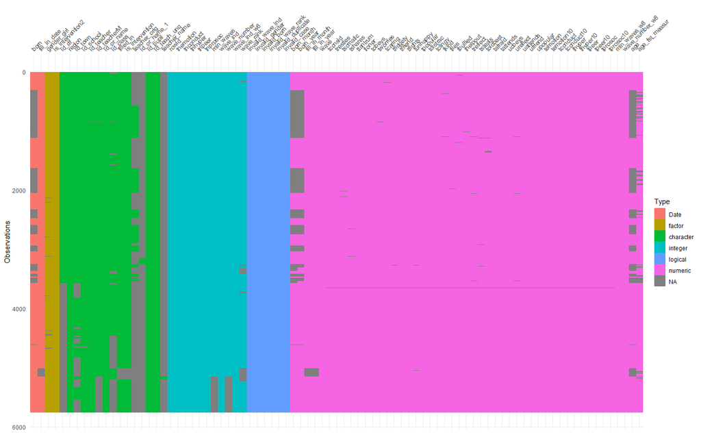

```r
vis_dat(dfm) # visualize types of variables
```

### 2.7.1 Intervention by birthday

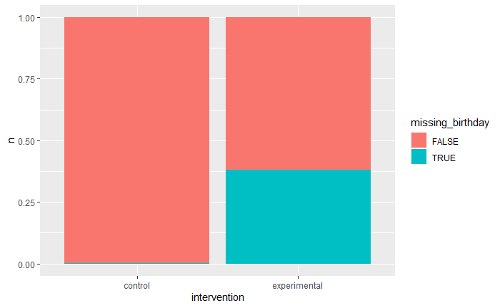

```r
dfm %>% count(missing_birthday = is.na(born), intervention = is_intervention2) %>%
  ggplot(aes(x = intervention, y = n, fill = missing_birthday)) +
  geom_bar(position = "fill", stat = "identity")
```

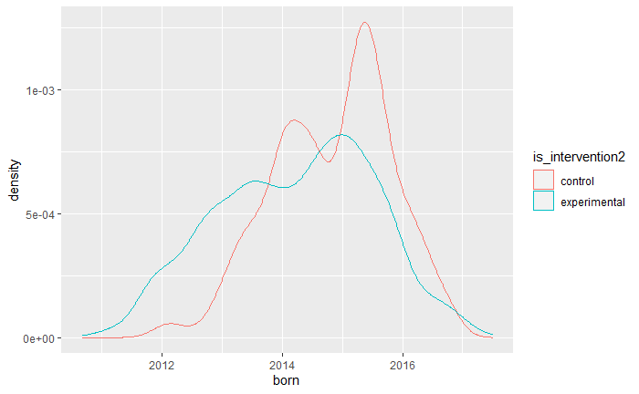

```r
dfm %>% ggplot(aes(born, col = is_intervention2)) + geom_density()
```

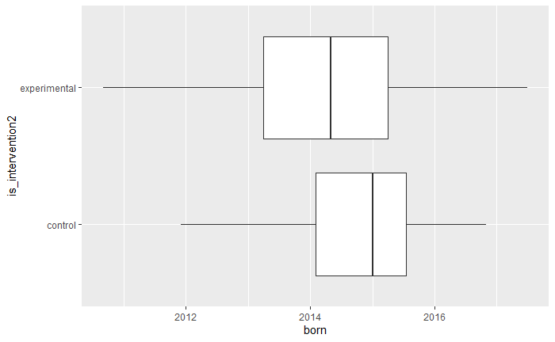

```r
dfm %>% ggplot(aes(born, is_intervention2)) + geom_boxplot()
```

### 2.7.2 Gender

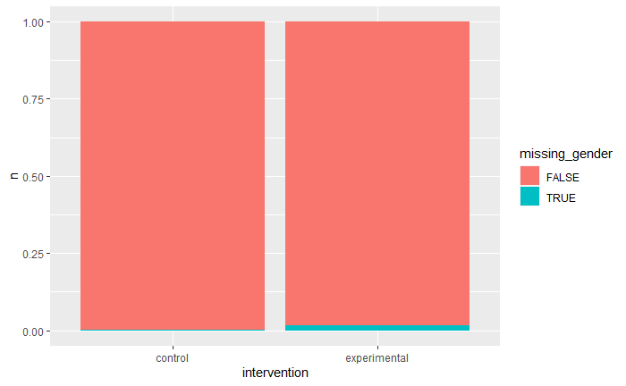

```r
dfm %>% count(missing_gender = is.na(gender_girl), intervention = is_intervention2) %>%
  ggplot(aes(x = intervention, y = n, fill = missing_gender)) +
  geom_bar(position = "fill", stat = "identity")
```

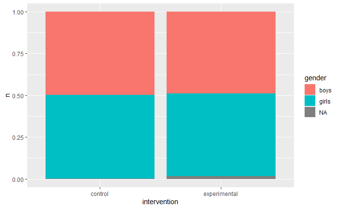

```r
dfm %>% count(gender = gender_girl, intervention = is_intervention2) %>%
  ggplot(aes(x = intervention, y = n, fill = gender)) +
  geom_bar(position = "fill", stat = "identity")
```

### 2.7.3 Age, intervention and SDQ

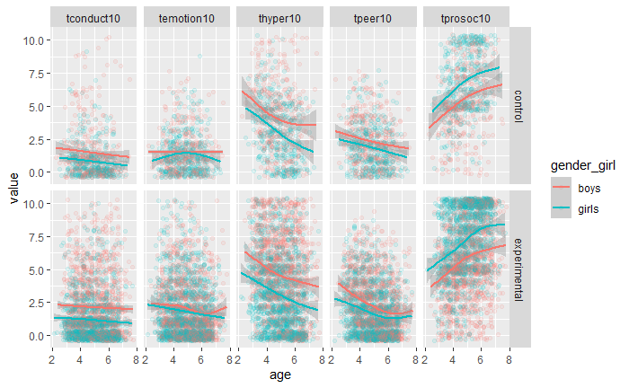

```r
dfm %>%
  drop_na(gender_girl) %>%
  pivot_longer(contains("10")) %>%
  ggplot(aes(age, value, col = gender_girl)) +
  geom_jitter(alpha = .1) +
  geom_smooth() +
  facet_grid(is_intervention2 ~ name)
```

### 2.7.4 SDQ dimensions distributions by gender

> A skew no one can undo…

First measurement only:

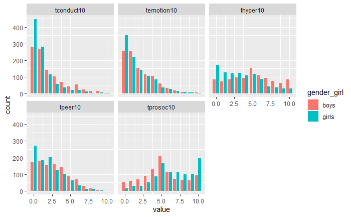

```r
dfm %>% filter(wave_ind == 1) %>%
  drop_na(gender_girl) %>%
  select(id_pupil, gender_girl, is_intervention2, contains("10")) %>%
  pivot_longer(contains("10")) %>%
  ggplot(aes(value, fill = gender_girl)) +
  geom_bar(position = "dodge2") +
  facet_wrap(~ name)
```

Second measurement only:

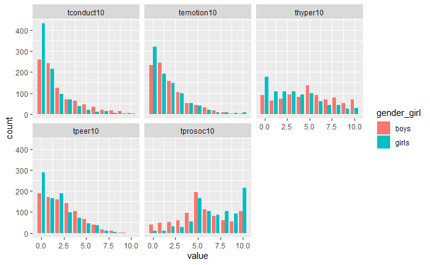

```r
dfm %>% filter(wave_ind == 2) %>%
  drop_na(gender_girl) %>%
  select(id_pupil, gender_girl, is_intervention2, contains("10")) %>%
  pivot_longer(contains("10")) %>%
  ggplot(aes(value, fill = gender_girl)) +
  geom_bar(position = "dodge2") +
  facet_wrap(~ name)
```